# Stroke_Project

Thushara_NV

05-22-2022

```r
#install the required packages and libraries
library(data.table)
library(caret)
#Library to read excel files
library("readxl")
library(readr)
library(ggplot2)
library(multcompView)
library(dplyr)
library (psych)
library(summarytools)
library(ggfortify)
library(gtsummary)
library(car)
library(tidyverse)
library(MASS)
# install.packages("corrplot")
library(corrplot)
#Eigen Values
library("factoextra")
#balance the class variable
library(imbalance)
#Variable importance
library(vip)
library(pROC)
#The dataset can be found #https://www.kaggle.com/datasets/fedesoriano/stroke-prediction-dataset #Load the .csv file from directory to data.
data <-  fread("C:\\Users\\prmen\\Desktop\\Thushara\\MSDS\\STAT613_APPLIED MULTIVARIATE STATISTICS\\project\\healthcare-dataset-stroke-data.csv")
```

**Data Cleaning and EDA:** The id variable can be dropped since it can’t provide any useful. information for the analysis.

```r
#Data Cleaning
#Drop Column ID
stroke = subset(data, select = -c(id))
View(stroke)
#Transfer column bmi to number
suppressWarnings(stroke$bmi <- as.numeric(as.character(stroke$bmi)))
summary(stroke)
```

```
##     gender               age         hypertension     heart_disease
##  Length:5110        Min.   : 0.08   Min.   :0.00000   Min.   :0.00000
##  Class :character   1st Qu.:25.00   1st Qu.:0.00000   1st Qu.:0.00000
##  Mode  :character   Median :45.00   Median :0.00000   Median :0.00000
##                     Mean   :43.23   Mean   :0.09746   Mean   :0.05401
##                     3rd Qu.:61.00   3rd Qu.:0.00000   3rd Qu.:0.00000
##                     Max.   :82.00   Max.   :1.00000   Max.   :1.00000
##
##  ever_married        work_type         Residence_type     avg_glucose_level
##  Length:5110        Length:5110        Length:5110        Min.   : 55.12
##  Class :character   Class :character   Class :character   1st Qu.: 77.25
##  Mode  :character   Mode  :character   Mode  :character   Median : 91.89
##                                                           Mean   :106.15
##                                                           3rd Qu.:114.09
##                                                           Max.   :271.74
##
##       bmi        smoking_status         stroke
##  Min.   :10.30   Length:5110        Min.   :0.00000
##  1st Qu.:23.50   Class :character   1st Qu.:0.00000
##  Median :28.10   Mode  :character   Median :0.00000
##  Mean   :28.89                      Mean   :0.04873
##  3rd Qu.:33.10                      3rd Qu.:0.00000
##  Max.   :97.60                      Max.   :1.00000
##  NA's   :201
```

```r
str(stroke)
```

```
## Classes 'data.table' and 'data.frame':   5110 obs. of  11 variables:
##  $ gender           : chr  "Male" "Female" "Male" "Female" ...
##  $ age              : num  67 61 80 49 79 81 74 69 59 78 ...
##  $ hypertension     : int  0 0 0 0 1 0 1 0 0 0 ...
##  $ heart_disease    : int  1 0 1 0 0 0 1 0 0 0 ...
##  $ ever_married     : chr  "Yes" "Yes" "Yes" "Yes" ...
##  $ work_type        : chr  "Private" "Self-employed" "Private" "Private" ...
##  $ Residence_type   : chr  "Urban" "Rural" "Rural" "Urban" ...
##  $ avg_glucose_level: num  229 202 106 171 174 ...
##  $ bmi              : num  36.6 NA 32.5 34.4 24 29 27.4 22.8 NA 24.2 ...
##  $ smoking_status   : chr  "formerly smoked" "never smoked" "never smoked" "smokes" ...
##  $ stroke           : int  1 1 1 1 1 1 1 1 1 1 ...
##  - attr(*, ".internal.selfref")=<externalptr>
```

```r
# Check for null
colSums(is.na(stroke))
```

```
##            gender               age      hypertension     heart_disease
##                 0                 0                 0                 0
##      ever_married         work_type    Residence_type avg_glucose_level
##                 0                 0                 0                 0
##               bmi    smoking_status            stroke
##               201                 0                 0
```

```r
# replace the bmi with the median.
bmi.median= median(stroke$bmi, na.rm = TRUE)
stroke$bmi<- replace(stroke$bmi, is.na(stroke$bmi), bmi.median)
# Examine column gender
as.data.frame(table(stroke$gender))
# Drop the column with 'other'.(Since there is only 1 row)
stroke = stroke[!gender == 'Other',]
# Examine work_type
as.data.frame(table(stroke$work_type))
# Examine residence_type
as.data.frame(table(stroke$Residence_type))
# Examine ever_married
as.data.frame(table(stroke$ever_married))
# Examine smoking
as.data.frame(table(stroke$smoking_status))
#checking null values
head(stroke)
colSums(is.na(stroke))
```

```r
#For the second part of the EDA, we need to transform columns for future analysis.
#For 0-1 binary variables, we would transform them into factors.
# Save a copy of the dataset
stroke1 <- copy(stroke)
# Transform binary variables to factor
stroke$stroke <- as.factor(stroke$stroke)
stroke$hypertension <- as.factor(stroke$hypertension)
stroke$heart_disease <- as.factor(stroke$heart_disease)
stroke$ever_married <- as.factor(stroke$ever_married)
stroke$gender <- as.factor(stroke$gender)
stroke$Residence_type <- as.factor(stroke$Residence_type)
stroke_numeric <- copy(stroke)
stroke_numeric$work_type <- as.factor(stroke_numeric$work_type)
stroke_numeric$smoking_status <- as.factor(stroke_numeric$smoking_status)
```

The correlation plot is used to identify the initial correlation among the different variables and to response variable ‘stroke’. The strength of the linear relationship between any two variables in the given data will be determined by the correlation value.

```r
# Transform binary variables to numeric as corrplot takes only numerical data
stroke_numeric$gender <- as.numeric(stroke_numeric$gender)
stroke_numeric$hypertension <-as.numeric(stroke_numeric$hypertension)
stroke_numeric$heart_disease <-as.numeric(stroke_numeric$heart_disease)
stroke_numeric$ever_married <- as.numeric(stroke_numeric$ever_married)
stroke_numeric$work_type <- as.numeric(stroke_numeric$work_type)
stroke_numeric$Residence_type <- as.numeric(stroke_numeric$Residence_type)
stroke_numeric$smoking_status <- as.numeric(stroke_numeric$smoking_status)
stroke_numeric$stroke <- as.numeric(stroke_numeric$stroke)
str(stroke_numeric)
summary(stroke_numeric)
colnames(stroke_numeric)
stroke_numeric$age<-sqrt(stroke_numeric$age+0.5)
stroke_numeric$avg_glucose_level<-log(stroke_numeric$avg_glucose_level+1)
stroke_numeric$bmi<-log(stroke_numeric$bmi+1)
describe(stroke_numeric)
summary(stroke_numeric)
```

There is a significant correlation between a patient’s marital status and their age with a 0.71 correlation index and that’s the highest correlation. There is also a positive correlation between patients’ age and the type of their work with a 0.61 correlation index. Also, age shows not high but positive correlation between hypertension and heart disease, bmi and average glucose level, stroke, and negative correlation to smoking_status. The type of residence of a patient is not correlated with any other attribute. There is also a moderate correlation between work_type and ever_married variables. Only age has a highly significant correlation with some of the other variables and that’s obvious. Thus, each feature might have its own individual contribution to the prediction of stroke.

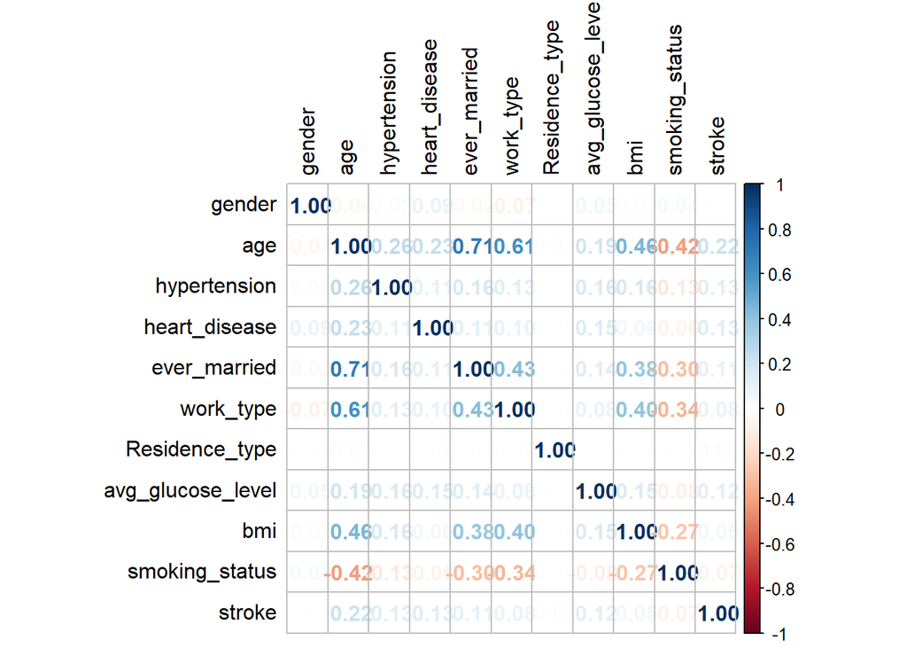

```r
#Correlation plot to identify how the variables are correlated

corrplot(cor(stroke_numeric),        # Correlation matrix
         method = "number", # Correlation plot method
         type = "full",    # Correlation plot style (also "upper" and "lower")
         diag = TRUE,      # If TRUE (default), adds the diagonal
         tl.col = "black", # Labels color
         bg = "white",     # Background color
         title = "",       # Main title
         col = NULL)       # Color palette
```

**Principal Component Analysis:** The summary of PCA is given below in figure.5. In this multivariate analysis, the dataset is transformed into a set of values of linearly uncorrelated variables called principal components. The cumulative proportion of variance explained by different PCs can be observed in figure.5 above. Out of 10 principal components, the first 6 PCs are required to explain 78.14% of variance cumulatively. A scree plot and a cumulative proportion of variance graph are shown in figure.6. It is clear that at least 6 PCS are required to explain about 78% of the variance and 7 are required for explaining 86% variance.

```r
attributes1<- dplyr::select(stroke_numeric,gender,age, hypertension,heart_disease,ever_married,
                            work_type,Residence_type,avg_glucose_level,bmi,smoking_status)
#PCA after standardization
stroke_data_s<-scale(attributes1)
summary(stroke_data_s)
```

```r
pcattrib_stroke<- prcomp(stroke_data_s)
summary(pcattrib_stroke)
```

```
## Importance of components:
##                           PC1    PC2    PC3    PC4     PC5     PC6     PC7
## Standard deviation     1.7170 1.0940 1.0006 0.9690 0.94273 0.91670 0.86589
## Proportion of Variance 0.2948 0.1197 0.1001 0.0939 0.08887 0.08403 0.07498
## Cumulative Proportion  0.2948 0.4145 0.5146 0.6085 0.69739 0.78142 0.85640
##                            PC8     PC9    PC10
## Standard deviation     0.80361 0.74872 0.47918
## Proportion of Variance 0.06458 0.05606 0.02296
## Cumulative Proportion  0.92098 0.97704 1.00000
```

```r
factloadts <- pcattrib_stroke$rotation
factloadts
eig.val1s <- get_eigenvalue(pcattrib_stroke)
eig.val1s
```

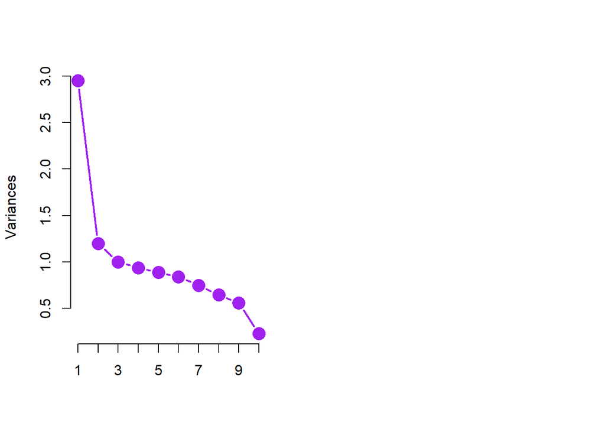

```r
# Construct scree plot
par(mfrow=c(1,2))
screeplot(pcattrib_stroke, col="purple", pch=16, type="lines",
          cex=2, lwd=2, main="")
```

```r
# Variability of each principal component: pr.var
pr.varts <-pcattrib_stroke$sdev^2
# Variance explained by each principal component: pve
pvets <- pr.varts / sum(pr.varts)
pvets
```

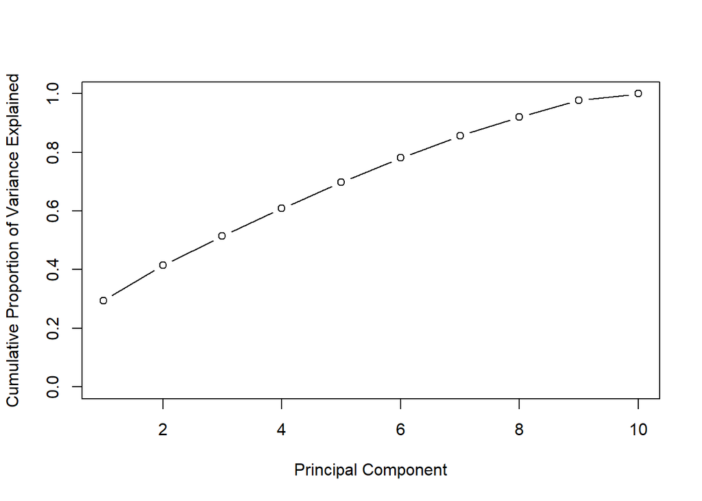

```r
# Plot cumulative proportion of variance explained
plot(cumsum(pvets), xlab = "Principal Component",
     ylab = "Cumulative Proportion of Variance Explained",
     ylim = c(0, 1), type = "b")
```

```r
pcattrib_stroke$x
factloadts <- pcattrib_stroke$rotation
factloadts
```

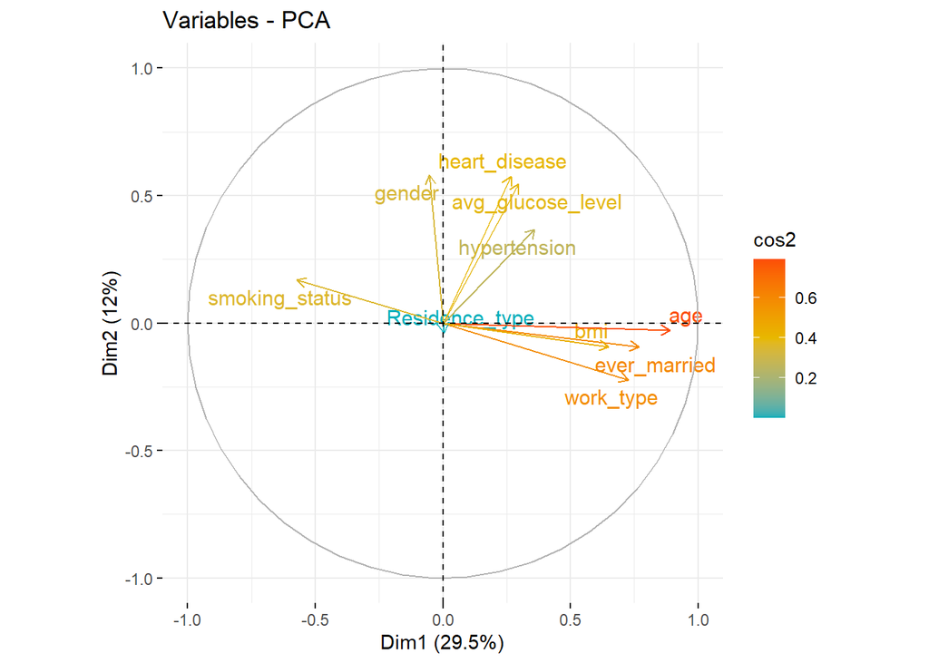

```r
# Color by cos2 values: quality on the factor map
fviz_pca_var(pcattrib_stroke, col.var = "cos2",
             gradient.cols = c("#00AFBB", "#E7B800", "#FC4E07"),
             repel = TRUE # Avoid text overlapping
)
```

```r
pca_regress_data <- cbind(stroke_numeric$stroke, pcattrib_stroke$x)

# Convery into data frame prior to analysis
#PCA regression
pca_regress_df <- as.data.frame(pca_regress_data)

# Specify multivariate regression model statement and perform analysis
# Print out analysis summary, fitted values, residuals, coefficients,
# variance-covariance matrix, etc...
pcareg1 <- glm(stroke_numeric$stroke~PC1+PC2+PC3+PC4+PC5+PC6+PC7, data=pca_regress_df)
summary(pcareg1)
```

```
##
## Call:
## glm(formula = stroke_numeric$stroke ~ PC1 + PC2 + PC3 + PC4 +
##     PC5 + PC6 + PC7, data = pca_regress_df)
##
## Coefficients:
##               Estimate Std. Error t value Pr(>|t|)
## (Intercept)  1.0487375  0.0029354 357.267  < 2e-16 ***
## PC1          0.0222684  0.0017098  13.024  < 2e-16 ***
## PC2          0.0233677  0.0026835   8.708  < 2e-16 ***
## PC3         -0.0047931  0.0029338  -1.634 0.102379
## PC4         -0.0110848  0.0030295  -3.659 0.000256 ***
## PC5          0.0115291  0.0031141   3.702 0.000216 ***
## PC6         -0.0065725  0.0032025  -2.052 0.040191 *
## PC7         -0.0003197  0.0033904  -0.094 0.924873
## ---
## Signif. codes:  0 '***' 0.001 '**' 0.01 '*' 0.05 '.' 0.1 ' ' 1
##
## (Dispersion parameter for gaussian family taken to be 0.0440233)
##
##     Null deviance: 236.86  on 5108  degrees of freedom
## Residual deviance: 224.56  on 5101  degrees of freedom
## AIC: -1446.9
##
## Number of Fisher Scoring iterations: 2
```

```r
plot(pcareg1)
```

[output not shown]

```r
#model linear regression model
model_lr <- glm(as.factor(stroke) ~.,family=binomial(link='logit'), data=stroke_numeric)
summary(model_lr)
```

```
##
## Call:
## glm(formula = as.factor(stroke) ~ ., family = binomial(link = "logit"),
##     data = stroke_numeric)
##
## Coefficients:
##                    Estimate Std. Error z value Pr(>|z|)
## (Intercept)       -13.61325    1.57637  -8.636  < 2e-16 ***
## gender              0.04948    0.13975   0.354 0.723327
## age                 1.05690    0.08480  12.463  < 2e-16 ***
## hypertension        0.39956    0.16307   2.450 0.014277 *
## heart_disease       0.33990    0.18874   1.801 0.071717 .
## ever_married       -0.26751    0.21867  -1.223 0.221200
## work_type          -0.07805    0.07192  -1.085 0.277785
## Residence_type      0.09975    0.13735   0.726 0.467680
## avg_glucose_level   0.53436    0.16202   3.298 0.000973 ***
## bmi                -0.02881    0.36328  -0.079 0.936782
## smoking_status      0.01831    0.06607   0.277 0.781728
## ---
## Signif. codes:  0 '***' 0.001 '**' 0.01 '*' 0.05 '.' 0.1 ' ' 1
##
## (Dispersion parameter for binomial family taken to be 1)
##
##     Null deviance: 1990.3  on 5108  degrees of freedom
## Residual deviance: 1590.2  on 5098  degrees of freedom
## AIC: 1612.2
##
## Number of Fisher Scoring iterations: 8
```

```r
#variance inflation factor to identify the multicollinearity VIF>10
vif(model_lr)
```

```
##            gender               age      hypertension     heart_disease
##          1.025588          1.167755          1.057167          1.080099
##      ever_married         work_type    Residence_type avg_glucose_level
##          1.033072          1.048018          1.004075          1.094174
##               bmi    smoking_status
##          1.064474          1.022036
```

```r
add_vif(tbl_regression(model_lr))
```

| **Characteristic** | **log(OR)**<sup>1</sup> | **95% CI**<sup>1</sup> | **p-value** | **VIF**<sup>1</sup> |
| --- | --- | --- | --- | --- |
| gender | 0.05 | -0.23, 0.32 | 0.7 | 1.0 |
| age | 1.1 | 0.90, 1.2 | <0.001 | 1.2 |
| hypertension | 0.40 | 0.07, 0.71 | 0.014 | 1.1 |
| heart_disease | 0.34 | -0.04, 0.70 | 0.072 | 1.1 |
| ever_married | -0.27 | -0.68, 0.18 | 0.2 | 1.0 |
| work_type | -0.08 | -0.22, 0.07 | 0.3 | 1.0 |
| Residence_type | 0.10 | -0.17, 0.37 | 0.5 | 1.0 |
| avg_glucose_level | 0.53 | 0.22, 0.85 | <0.001 | 1.1 |
| bmi | -0.03 | -0.74, 0.68 | >0.9 | 1.1 |
| smoking_status | 0.02 | -0.11, 0.15 | 0.8 | 1.0 |

<sup>1</sup> OR = Odds Ratio, CI = Confidence Interval, VIF = Variance Inflation Factor

```r
#Stepwise regression to see which factors contribute to the final model
stepAIC(model_lr)
```

```
## Start:  AIC=1612.25
## as.factor(stroke) ~ gender + age + hypertension + heart_disease +
##     ever_married + work_type + Residence_type + avg_glucose_level +
##     bmi + smoking_status
##
##                     Df Deviance    AIC
## - bmi                1   1590.2 1610.2
## - smoking_status     1   1590.3 1610.3
## - gender             1   1590.4 1610.4
## - Residence_type     1   1590.8 1610.8
## - work_type          1   1591.4 1611.4
## - ever_married       1   1591.7 1611.7
## <none>                   1590.2 1612.2
## - heart_disease      1   1593.4 1613.4
## - hypertension       1   1596.0 1616.0
## - avg_glucose_level  1   1601.0 1621.0
## - age                1   1802.9 1822.9
##
## Step:  AIC=1610.25
## as.factor(stroke) ~ gender + age + hypertension + heart_disease +
##     ever_married + work_type + Residence_type + avg_glucose_level +
##     smoking_status
##
##                     Df Deviance    AIC
## - smoking_status     1   1590.3 1608.3
## - gender             1   1590.4 1608.4
## - Residence_type     1   1590.8 1608.8
## - work_type          1   1591.4 1609.4
## - ever_married       1   1591.7 1609.7
## <none>                   1590.2 1610.2
## - heart_disease      1   1593.4 1611.4
## - hypertension       1   1596.0 1614.0
## - avg_glucose_level  1   1601.3 1619.3
## - age                1   1803.8 1821.8
##
## Step:  AIC=1608.33
## as.factor(stroke) ~ gender + age + hypertension + heart_disease +
##     ever_married + work_type + Residence_type + avg_glucose_level
##
##                     Df Deviance    AIC
```

[output cut: 43 more lines]

```
## <none>                   1592.2 1604.2
## - heart_disease      1   1595.4 1605.4
## - hypertension       1   1597.6 1607.6
## - avg_glucose_level  1   1603.5 1613.5
## - age                1   1815.0 1825.0
##
## Step:  AIC=1603.63
## as.factor(stroke) ~ age + hypertension + heart_disease + avg_glucose_level
##
##                     Df Deviance    AIC
## <none>                   1593.6 1603.6
## - heart_disease      1   1597.1 1605.1
## - hypertension       1   1599.1 1607.1
## - avg_glucose_level  1   1604.6 1612.6
## - age                1   1852.2 1860.2
```

```
##
## Call:  glm(formula = as.factor(stroke) ~ age + hypertension + heart_disease +
##     avg_glucose_level, family = binomial(link = "logit"), data = stroke_numeric)
##
## Coefficients:
##       (Intercept)                age       hypertension      heart_disease
##          -13.9901             1.0268             0.3870             0.3543
## avg_glucose_level
##            0.5278
##
## Degrees of Freedom: 5108 Total (i.e. Null);  5104 Residual
## Null Deviance:       1990
## Residual Deviance: 1594  AIC: 1604
```

```r
model_aic<- glm(formula = as.factor(stroke) ~ age + hypertension + heart_disease +
                  avg_glucose_level, family = binomial(link = "logit"), data = stroke_numeric)
summary(model_aic)
```

```
##
## Call:
## glm(formula = as.factor(stroke) ~ age + hypertension + heart_disease +
##     avg_glucose_level, family = binomial(link = "logit"), data = stroke_numeric)
##
## Coefficients:
##                    Estimate Std. Error z value Pr(>|z|)
## (Intercept)       -13.99007    0.93483 -14.965  < 2e-16 ***
## age                 1.02677    0.08233  12.471  < 2e-16 ***
## hypertension        0.38699    0.16167   2.394 0.016681 *
## heart_disease       0.35435    0.18667   1.898 0.057667 .
## avg_glucose_level   0.52778    0.15803   3.340 0.000839 ***
## ---
## Signif. codes:  0 '***' 0.001 '**' 0.01 '*' 0.05 '.' 0.1 ' ' 1
##
## (Dispersion parameter for binomial family taken to be 1)
##
##     Null deviance: 1990.3  on 5108  degrees of freedom
## Residual deviance: 1593.6  on 5104  degrees of freedom
## AIC: 1603.6
##
## Number of Fisher Scoring iterations: 8
```

```r
table(stroke_numeric$stroke)
```

```
##
##    1    2
## 4860  249
```

```r
oversampled <- mwmote(stroke_numeric, classAttr = "stroke", numInstances = 500)
oversampled <- round(oversampled)
```

```r
set.seed(1203)
fullData <- rbind(stroke_numeric, oversampled)
str(fullData)
```

```
## Classes 'data.table' and 'data.frame':   5609 obs. of  11 variables:
##  $ gender           : num  2 1 2 1 1 2 2 1 1 1 ...
##  $ age              : num  8.22 7.84 8.97 7.04 8.92 ...
##  $ hypertension     : num  1 1 1 1 2 1 2 1 1 1 ...
##  $ heart_disease    : num  2 1 2 1 1 1 2 1 1 1 ...
##  $ ever_married     : num  2 2 2 2 2 2 2 1 2 2 ...
##  $ work_type        : num  4 5 4 4 5 4 4 4 4 4 ...
##  $ Residence_type   : num  2 1 1 2 1 2 1 2 1 2 ...
##  $ avg_glucose_level: num  5.44 5.31 4.67 5.15 5.17 ...
##  $ bmi              : num  3.63 3.37 3.51 3.57 3.22 ...
##  $ smoking_status   : num  1 2 2 3 2 1 2 2 4 4 ...
##  $ stroke           : num  2 2 2 2 2 2 2 2 2 2 ...
##  - attr(*, ".internal.selfref")=<externalptr>
```

```r
# Target class needs to be a factor
fullData$stroke <- factor(fullData$stroke)
#train-test split
sample <- createDataPartition(y = fullData$stroke, p = 0.7, list = FALSE)
train <- fullData[sample, ]
test <- fullData[-sample, ]
dim(train)
```

```
## [1] 3927   11
```

```r
dim(test)
```

```
## [1] 1682   11
```

```r
#logistic regression model
train_control <- trainControl(method = "cv", number = 5)
logisticRegression <- train(stroke~., data = train, method = "glm",
                            trControl = train_control,
                            family = "binomial")
logisticRegression
```

```
## Generalized Linear Model
##
## 3927 samples
##   10 predictor
##    2 classes: '1', '2'
##
## No pre-processing
## Resampling: Cross-Validated (5 fold)
## Summary of sample sizes: 3142, 3141, 3141, 3142, 3142
## Resampling results:
##
##   Accuracy   Kappa
##   0.8828619  0.3492056
```

```r
p1<-predict(logisticRegression,(test))
str(p1)
```

```
##  Factor w/ 2 levels "1","2": 2 1 1 1 1 1 1 1 1 1 ...
```

```r
confusionMatrix(p1,as.factor(test$stroke),mode="everything")
```

```
## Confusion Matrix and Statistics
##
##           Reference
## Prediction    1    2
##          1 1416  160
##          2   42   64
##
##                Accuracy : 0.8799
##                  95% CI : (0.8634, 0.8951)
##     No Information Rate : 0.8668
##     P-Value [Acc > NIR] : 0.05988
##
##                   Kappa : 0.3306
##
##  Mcnemar's Test P-Value : < 2e-16
##
##             Sensitivity : 0.9712
##             Specificity : 0.2857
##          Pos Pred Value : 0.8985
##          Neg Pred Value : 0.6038
##               Precision : 0.8985
##                  Recall : 0.9712
##                      F1 : 0.9334
##              Prevalence : 0.8668
##          Detection Rate : 0.8419
##    Detection Prevalence : 0.9370
##       Balanced Accuracy : 0.6285
##
##        'Positive' Class : 1
##
```

```r
str(test$stroke)
```

```
##  Factor w/ 2 levels "1","2": 2 2 2 2 2 2 2 2 2 2 ...
```

```r
#random forest model
randomForest <- train(stroke ~ ., data = train, method = "rf", trControl = train_control)
randomForest
```

```
## Random Forest
##
## 3927 samples
##   10 predictor
##    2 classes: '1', '2'
##
## No pre-processing
## Resampling: Cross-Validated (5 fold)
## Summary of sample sizes: 3141, 3142, 3141, 3142, 3142
## Resampling results across tuning parameters:
##
##   mtry  Accuracy   Kappa
##    2    0.9544192  0.7718211
##    6    0.9518731  0.7622192
##   10    0.9505992  0.7575119
##
## Accuracy was used to select the optimal model using the largest value.
## The final value used for the model was mtry = 2.
```

```r
p1_rf<-predict(randomForest,(test))
str(p1_rf)
```

```
##  Factor w/ 2 levels "1","2": 1 1 1 1 1 1 1 1 1 1 ...
```

```r
confusionMatrix(p1_rf,as.factor(test$stroke),mode="everything")
```

```
## Confusion Matrix and Statistics
##
##           Reference
## Prediction    1    2
##          1 1458   74
##          2    0  150
##
##                Accuracy : 0.956
##                  95% CI : (0.9451, 0.9653)
##     No Information Rate : 0.8668
##     P-Value [Acc > NIR] : < 2.2e-16
##
##                   Kappa : 0.7785
##
##  Mcnemar's Test P-Value : < 2.2e-16
##
##             Sensitivity : 1.0000
##             Specificity : 0.6696
##          Pos Pred Value : 0.9517
##          Neg Pred Value : 1.0000
##               Precision : 0.9517
##                  Recall : 1.0000
##                      F1 : 0.9753
##              Prevalence : 0.8668
##          Detection Rate : 0.8668
##    Detection Prevalence : 0.9108
##       Balanced Accuracy : 0.8348
##
##        'Positive' Class : 1
##
```

```r
str(test$stroke)
```

```
##  Factor w/ 2 levels "1","2": 2 2 2 2 2 2 2 2 2 2 ...
```

```r
#K nearest neighbour
knn <- train(stroke~., data = train, method = "knn", trControl = train_control)
knn
```

```
## k-Nearest Neighbors
##
## 3927 samples
##   10 predictor
##    2 classes: '1', '2'
##
## No pre-processing
## Resampling: Cross-Validated (5 fold)
## Summary of sample sizes: 3142, 3142, 3142, 3141, 3141
## Resampling results across tuning parameters:
##
##   k  Accuracy   Kappa
##   5  0.8846482  0.4197946
##   7  0.8833769  0.3920324
##   9  0.8800635  0.3386421
##
## Accuracy was used to select the optimal model using the largest value.
## The final value used for the model was k = 5.
```

```r
p1_knn<-predict(knn,(test))
str(p1_knn)
```

```
##  Factor w/ 2 levels "1","2": 2 1 1 2 2 1 2 1 1 1 ...
```

```r
confusionMatrix(p1_knn,as.factor(test$stroke),mode="everything")
```

```
## Confusion Matrix and Statistics
##
##           Reference
## Prediction    1    2
##          1 1411  124
##          2   47  100
##
##                Accuracy : 0.8983
##                  95% CI : (0.8829, 0.9124)
##     No Information Rate : 0.8668
##     P-Value [Acc > NIR] : 4.853e-05
##
##                   Kappa : 0.4847
##
##  Mcnemar's Test P-Value : 6.178e-09
##
##             Sensitivity : 0.9678
##             Specificity : 0.4464
##          Pos Pred Value : 0.9192
##          Neg Pred Value : 0.6803
##               Precision : 0.9192
##                  Recall : 0.9678
##                      F1 : 0.9429
##              Prevalence : 0.8668
##          Detection Rate : 0.8389
##    Detection Prevalence : 0.9126
##       Balanced Accuracy : 0.7071
##
##        'Positive' Class : 1
##
```

```r
str(test$stroke)
```

```
##  Factor w/ 2 levels "1","2": 2 2 2 2 2 2 2 2 2 2 ...
```

```r
#svm
library(e1071)
svm_model<-svm(stroke~.,data=train,trControl = train_control)
summary(svm_model)
```

```
##
## Call:
## svm(formula = stroke ~ ., data = train, trControl = train_control)
##
##
## Parameters:
##    SVM-Type:  C-classification
##  SVM-Kernel:  radial
##        cost:  1
##
## Number of Support Vectors:  892
##
##  ( 423 469 )
##
##
## Number of Classes:  2
##
## Levels:
##  1 2
```

```r
#predicting values
pred_svm<-predict(svm_model,test)
#Confusion Matrix
confusionMatrix(pred_svm,as.factor(test$stroke),mode="everything")
```

```
## Confusion Matrix and Statistics
##
##           Reference
## Prediction    1    2
##          1 1438   88
##          2   20  136
##
##                Accuracy : 0.9358
##                  95% CI : (0.923, 0.947)
##     No Information Rate : 0.8668
##     P-Value [Acc > NIR] : < 2.2e-16
##
##                   Kappa : 0.6809
##
##  Mcnemar's Test P-Value : 1.14e-10
##
##             Sensitivity : 0.9863
##             Specificity : 0.6071
##          Pos Pred Value : 0.9423
##          Neg Pred Value : 0.8718
##               Precision : 0.9423
##                  Recall : 0.9863
##                      F1 : 0.9638
##              Prevalence : 0.8668
##          Detection Rate : 0.8549
##    Detection Prevalence : 0.9073
##       Balanced Accuracy : 0.7967
##
##        'Positive' Class : 1
##
```

The variable importance is applied to Logistic Regression and Random Forest to see the important variables contributing more towards the prediction of stroke and the plot is given below. The more a model relies on a variable to make predictions, the more important it is for the model.

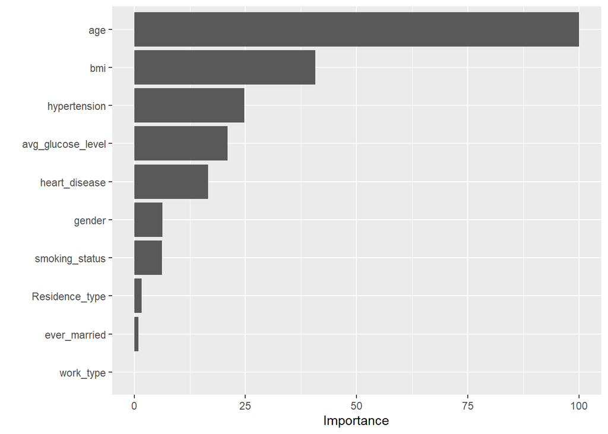

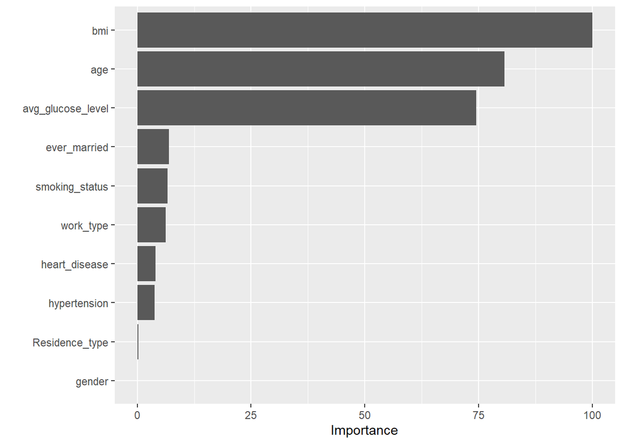

```r
par(mfrow=c(1,2))
vip(logisticRegression)
vip(randomForest)
```

```r
# Create a 2x2 layout for the ROC curves
par(mfrow=c(2,2))
# Plot the first ROC curve for SVM
test_roc1 = roc(as.numeric(test$stroke) ~ as.numeric(pred_svm),
                plot = TRUE, col = "red")
# Overlay the second ROC curve for KNN
test_roc2 = roc(as.numeric(test$stroke) ~ as.numeric(p1_knn),
                plot = TRUE, col = "green", add = TRUE)
# Overlay the third ROC curve for Random Forest
test_roc3 = roc(as.numeric(test$stroke) ~ as.numeric(p1_rf),
                plot = TRUE, col = "blue", add = TRUE)
# Overlay the fourth ROC curve for Logistic Regression
test_roc4 = roc(as.numeric(test$stroke) ~ as.numeric(p1),
                plot = TRUE, col = "black", add = TRUE)
```

The ROC curve and AUC value of the 4 different models are given in Figure. The higher the AUC value indicates the better model performance. The ROC curve indicates that the Random Forest classification has the better classification efficiency in distinguishing between patients susceptible to stroke and no stroke.

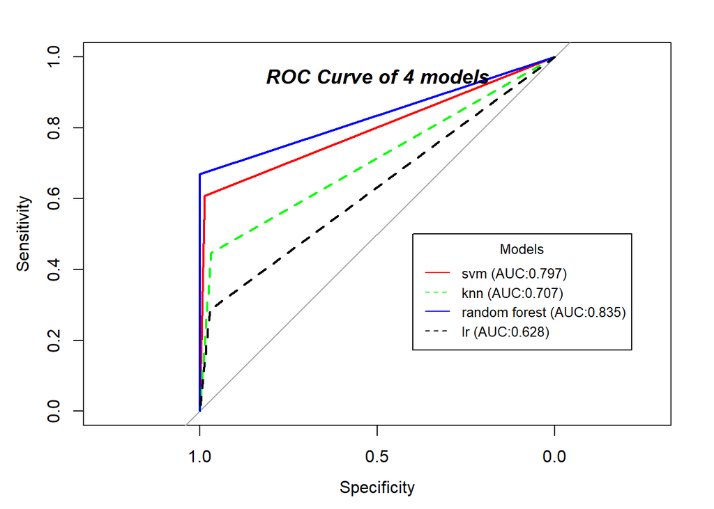

```r
# Combine all ROC curves into one plot
plot(test_roc1, col="red", lwd=2)
plot(test_roc2, add=TRUE, col="green", lwd=2, lty=2)
plot(test_roc3, add=TRUE, col="blue", lwd=2)
plot(test_roc4, add=TRUE, col="black", lwd=2, lty=2)
title(main="ROC Curve of 4 models", font.main=4, line=0)

# Range for the plot
plot_range <- range(0, 0.5, 0.5, 0.5, 0.5)

# Get the AUC values and round them
auc_values <- c(
  round(test_roc1$auc, digits=3),
  round(test_roc2$auc, digits=3),
  round(test_roc3$auc, digits=3),
  round(test_roc4$auc, digits=3)
)

# Create legend labels with AUC values
model_labels <- c("svm", "knn", "random forest", "lr")
auc_labels <- paste(model_labels, " (AUC:", auc_values, ")", sep="")

# Add legends for models and AUC values
legend(0.4, plot_range[2], auc_labels, cex=0.8,
       col=c("red", "green", "blue", "black"), lty=1:2, title="Models")
```

**Discussion:** The primary objective of this project is to find the different predictors given in the data set that can effectively identify the stroke event in patients so that it leads to better preventive care for patients who are susceptible to stroke. Using Logistic regression, we found that the major predictors are age, hypertension, heart_disease, and avg_glucose_level. Variable importance of Logistic Regression and Random Forest also revealed that age, bmi, and avg_glucose_level are the most significant variables for stroke prediction for the given data. Hypertension, smoking_status, and heart_disease are worth considering as important. Also, PCA is implemented to see whether the dimensionality can be reduced using a lower number of principal components but out of 10 variables, 7 are required to explain more than 80% of the variance explained by the original data. Then we balanced the data using the MWMOTE re-sampling technique and constructed models and reached a conclusion that Random Forest is the best model for the re-sampled data that has high Sensitivity and Specificity values which is crucial for stroke prediction. Better models must be developed since stroke is a serious life-threatening condition. Since the original data is highly imbalanced, more accurate data must be collected instead of applying re-sampling techniques. Varieties of other ML algorithms can also be implemented to see which one can perform better than the suggested Random Forest in this project.